# Bergen-Belsen Exhibition - Panel 6 Analysis

## 📊 Exploratory Data Analysis (EDA)

### 🕒 Time & Interaction Metrics

- **Time per Item**: Analyze the average time spent on each item.
- **Number of Interactions per Item**: Count and visualize interactions per item.
- **Overall Time per Session**: Compute and visualize total session durations.

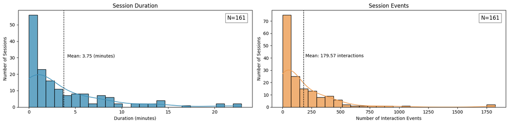

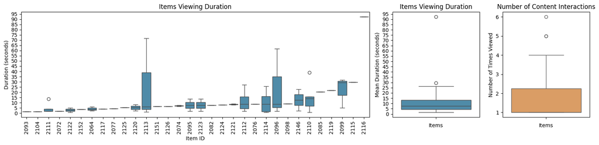

Table 1: Sessions filtered from analysis.

|  | filename | duration (hours) |
| --- | --- | --- |
| 37 | Log_Interactions_BB_1733166237738.json | 0.680947 |
| 142 | Log_Interactions_BB_1738071273547.json | 1.091853 |
| 92 | Log_Interactions_BB_1733663629768.json | 1.493222 |
| 147 | Log_Interactions_BB_1738143118211.json | 2.010710 |
| 38 | Log_Interactions_BB_1733196818450.json | 2.439833 |
| 61 | Log_Interactions_BB_1733276343990.json | 4.348444 |
| 77 | Log_Interactions_BB_1733546203534.json | 7.696333 |
| 167 | Log_Interactions_BB_1738546402070.json | 12.300317 |
| 74 | Log_Interactions_BB_1733448605022.json | 12.519861 |

### 🔍 Navigation & Engagement Patterns

- **Popularity of Items & Exhibitions**: Determine the most visited items and exhibitions.
- **Interest in Themes**: Analyze interaction time per exhibition to infer user interest.
- **Ratio of Exploration vs. Exhibition Engagement**: Calculate time spent exploring vs.engaging with content.

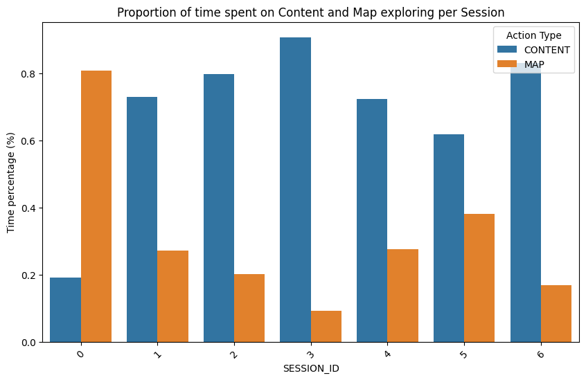

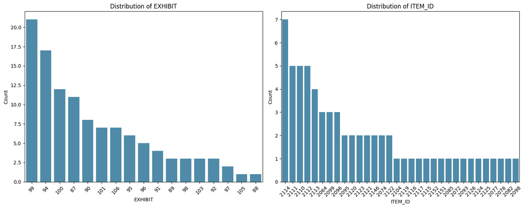

Table 2: Exhibit Names linked to Identifier.

[output not shown]

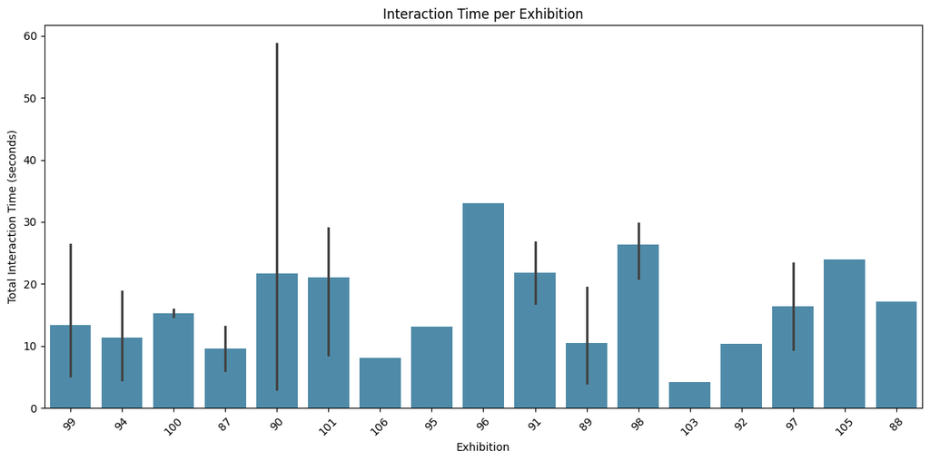

### 🎯 Visitor Segmentation & Engagement

- **Items per Session & Keyword Analysis**: Extract keywords from session items.
  - Generate word clouds per session.

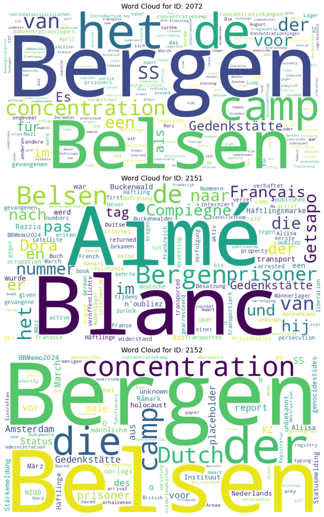

### Next Steps

**Relevant**

- **Threshold for New Visitors/Groups**: Define session segmentation based on inactivity (~1-2 min).

**Further Insights**

- **Patterns of Navigation**: Identify common user navigation paths.
  - Check for effect on content presentation order, by checking if the most viewed content is the one that is presented first.
- **Use of Visual Layers**: Track usage of layers (1944, 1945, 1944 aerial, memorial site 2014).
- **Alternative Content Engagement**: Look at alternative events when content is unavailable (e.g., content closed or visit finished).
- **Engagement Quantification**: Develop a global engagement metric based on time and interaction (touch).
- **Contextual Shift Analysis**: Define a metric for tracking user transitions between different types of content.